# Visualizing with Matplotlib and Seaborn

### Use of AI: can be used, but must be reported.

### AI shall not be used to complete the whole assignment.

```python
# Take necessary libraries in use.
import pandas as pd
import matplotlib.pyplot as plt
import seaborn as sns
```

## Load the penguins dataset and check info

```python
penguins = sns.load_dataset("penguins")
```

```python
penguins.info()
```

```
<class 'pandas.core.frame.DataFrame'>
RangeIndex: 344 entries, 0 to 343
Data columns (total 7 columns):
 #   Column             Non-Null Count  Dtype
---  ------             --------------  -----
 0   species            344 non-null    object
 1   island             344 non-null    object
 2   bill_length_mm     342 non-null    float64
 3   bill_depth_mm      342 non-null    float64
 4   flipper_length_mm  342 non-null    float64
 5   body_mass_g        342 non-null    float64
 6   sex                333 non-null    object
dtypes: float64(4), object(3)
memory usage: 18.9+ KB
```

## Tasks

### Task 0: Drop missing values and check they were dropped.

```python
# Your code here
penguins.dropna(inplace=True)
penguins
```

|  | species | island | bill_length_mm | bill_depth_mm | flipper_length_mm | body_mass_g | sex |
| --- | --- | --- | --- | --- | --- | --- | --- |
| 0 | Adelie | Torgersen | 39.1 | 18.7 | 181.0 | 3750.0 | Male |
| 1 | Adelie | Torgersen | 39.5 | 17.4 | 186.0 | 3800.0 | Female |
| 2 | Adelie | Torgersen | 40.3 | 18.0 | 195.0 | 3250.0 | Female |
| 4 | Adelie | Torgersen | 36.7 | 19.3 | 193.0 | 3450.0 | Female |
| 5 | Adelie | Torgersen | 39.3 | 20.6 | 190.0 | 3650.0 | Male |
| ... | ... | ... | ... | ... | ... | ... | ... |
| 338 | Gentoo | Biscoe | 47.2 | 13.7 | 214.0 | 4925.0 | Female |
| 340 | Gentoo | Biscoe | 46.8 | 14.3 | 215.0 | 4850.0 | Female |
| 341 | Gentoo | Biscoe | 50.4 | 15.7 | 222.0 | 5750.0 | Male |
| 342 | Gentoo | Biscoe | 45.2 | 14.8 | 212.0 | 5200.0 | Female |
| 343 | Gentoo | Biscoe | 49.9 | 16.1 | 213.0 | 5400.0 | Male |

333 rows × 7 columns

### Complete the following tasks using Matplotlib and Seaborn.

- Your task is to replicate the given plots using the penguins data.
- Plots are in Plots.html.
- You need to get all the labels, titles etc. elements to the plot.
- The size of the plot does not need to be exactly the same. As long as your plot is readable, it is fine.
- You do not need to guess the used colors, so feel free to choose the color palette you like. You can test different color palettes for different plots if you wish. https://seaborn.pydata.org/tutorial/color_palettes.html
- Use the hints and further instructions whenever given.
- Please do not give the plot to AI and ask for the code, but try to figure out yourself, what the plot is and how to construct it and what are the different elements called.
- Also try to understand what kind of information the plot tells.
- Self-made good try is better than perfect AI-generated outcome! Self-made good try is also better than empty task.
- Try to construct plot piece-by-piece. You do not need to get all the elements there at once. Run your code frequently and add things.

### Before asking AI, try to find answers from these quick start guides and tutorials (and check also previous assignments for hints):

Matplotlib quick start guide: https://matplotlib.org/stable/users/explain/quick_start.html

Seaborn introduction (especially parts about scatterplots and histograms): https://seaborn.pydata.org/tutorial/introduction.html

Seaborn tutorial: https://seaborn.pydata.org/tutorial/function_overview.html

### Task 1: Replicate the plot (SEE PLOTS FROM Plots.html).

- Hint: hue="species"

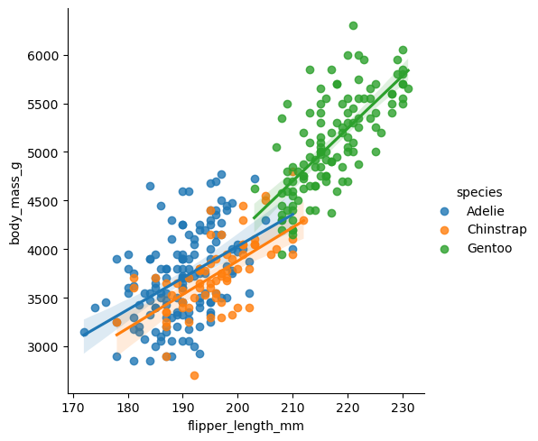

```python
# Your code here
ax = sns.lmplot(data=penguins, x="flipper_length_mm", y="body_mass_g", hue="species")
ax.set_titles("Body Mass vs Flipper Length by Species")
```

### Task 2: Replicate the plot.

- Hint: kde=True

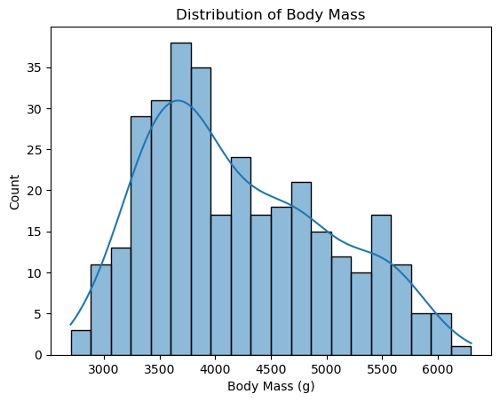

```python
# Your code here
ax = sns.histplot(data=penguins, x="body_mass_g", bins=20, kde=True)
ax.set_title("Distribution of Body Mass")
ax.set_xlabel("Body Mass (g)")
```

### Task 3: Replicate the plot.

- Hint: hue="species"
- Hint: plt.figure(figsize=(8, 5))

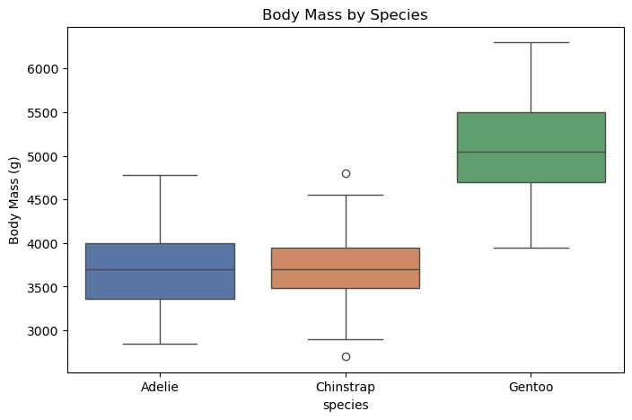

```python
# Your code here
plt.figure(figsize=(8, 5))
ax = sns.boxplot(data=penguins, x="species", y="body_mass_g", hue="species", palette="deep")
ax.set_title("Body Mass by Species")
ax.set_ylabel("Body Mass (g)")
```

### Task 4: Replicate the plot (it is a violin plot)

- Hint: sns.violinplot()
- Hint: hue="species"
- Find out, what does a violin plot tell (so that you understand the purpose and can read the plot).

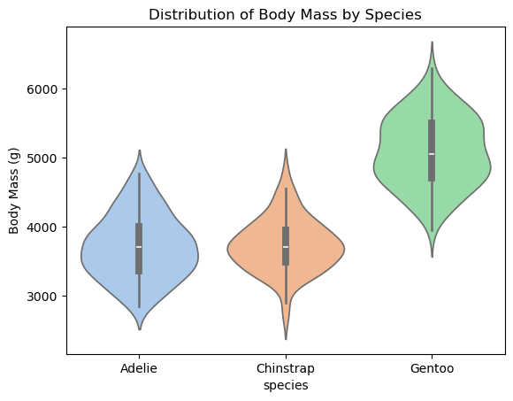

```python
# Your code here
ax = sns.violinplot(data=penguins, x="species", y="body_mass_g", hue="species", palette="pastel")
ax.set_title("Distribution of Body Mass by Species")
ax.set_ylabel("Body Mass (g)")
# The violin's body runs vertically (x=species, y=body_mass_g).
# Its width at a given height shows the DENSITY of penguins of that
# species at that body mass - a wider section means more records there.
```

### Task 5: Replicate the plot.

- Hint: bins=15
- Hint: alpha=0.6
- Hint: hue="species"

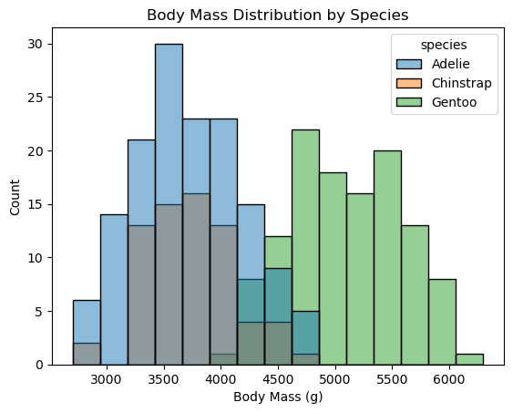

```python
# Your code here
ax = sns.histplot(data=penguins, x="body_mass_g", hue="species", bins=15)
ax.set_title("Body Mass Distribution by Species")
ax.set_xlabel("Body Mass (g)")
ax.set_alpha(0.6)
```

### Task 6: Replicate the plot.

- Hint: hue="species"

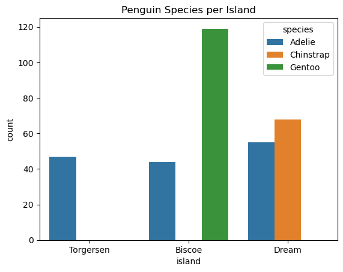

```python
# Your code here
ax = sns.countplot(data=penguins, x="island", hue="species")
ax.set_title("Penguin Species per Island")
```